# Find A Gene

Zach Goldberg

12/3/2019

```r
library(bio3d)
```

```r
aln <- read.fasta("Q5_MultipleAlignments.fasta")
aln$id <- c("Carp (Novel)", "Homo Sapien", "Zebrafish", "Pike", "Cod", "Tilapia", "Mouse", "Xenopus", "Gekko")
mat <- seqidentity(aln)
```

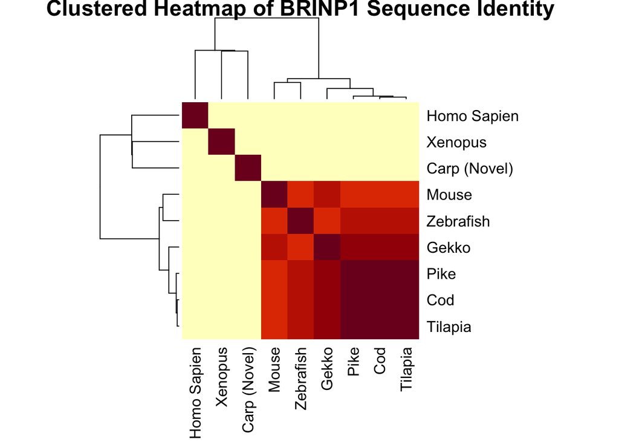

```r
heatmap(mat, symm = T, margins =  c(7,7), scale = "none",
        main = "Clustered Heatmap of BRINP1 Sequence Identity")
```

[Q8] Using R/Bio3D (or an online blast server if you prefer), search the main protein structure database for the most similar atomic resolution structures to your aligned sequences.

List the top 3 unique hits (i.e. not hits representing different chains from the same structure) along with their Evalue and sequence identity to your query. Please also add annotation details of these structures. For example, include the annotation terms PDB identifier (structureId), Method used to solve the structure (experimentalTechnique), resolution (resolution), and source organism (source).

HINT: You can use a single sequence from your alignment or generate a consensus sequence from your alignment using the Bio3D function consensus(). The Bio3D functions blast.pdb(), plot.blast() and pdb.annotate() are likely to be of most relevance for completing this task. Note that the results of blast.pdb() contain the hits PDB identifier (or pdb.id) as well as Evalue and identity. The results of pdb.annotate() contain the other annotation terms noted above.

Note that if your consensus sequence has lots of gap positions then it will be better to use an original sequence from the alignment for your search of the PDB. In this case you could chose the sequence with the highest identity to all others in your alignment by calculating the row-wise maximum from your sequence identity matrix.

```r
# Generate Consensus Sequence
con <- consensus(aln, cutoff = 0.6)

# How many positions are gaps?
gaps <- sum(con$seq == "-")
gaps
```

```
## [1] 280
```

```r
# What percent of the consensus sequence are gaps?
gaps/length(con$seq)
```

```
## [1] 0.357599
```

This is too many gaps. Instead, choose best match from rowSums of identity matrix

```r
row_sums <- rowSums(mat)
sort(row_sums, decreasing = TRUE)
```

```
##      Tilapia          Cod         Pike        Gekko    Zebrafish        Mouse
##        5.458        5.449        5.443        5.271        4.932        4.835
## Carp (Novel)      Xenopus  Homo Sapien
##        1.580        1.562        1.518
```

Use just the Tilapia sequence for PDB search

```r
tilapia <- read.fasta("NileTilapiaBrinp1.txt")
```

```r
blast_pdb <- blast.pdb(tilapia)
```

```
##  Searching ... please wait (updates every 5 seconds) RID = YGADNTVF014
##  ..
##  Reporting 14 hits
```

```r
write.csv(blast_pdb$hit.tbl, file = "BlastPDB.csv")
```

```
##   * Possible cutoff values:    0 -1 -1 -2 -2 -2 -3
##             Yielding Nhits:    1 2 3 4 5 7 14
##
##   * Chosen cutoff value of:    0
##             Yielding Nhits:    1
```

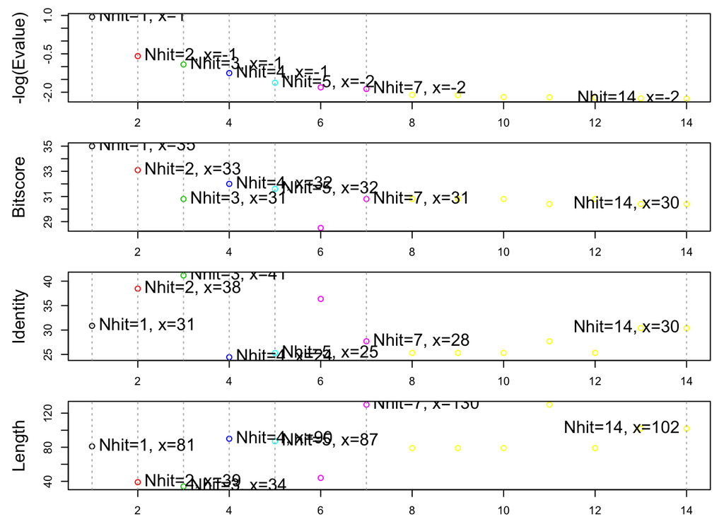

```r
plot.blast(blast_pdb)
```

```r
s <- substr(blast_pdb$hit.tbl$subjectids, 1, 4)
a <- pdb.annotate(blast_pdb$hit.tbl$subjectids)
a
```

```
##        structureId chainId experimentalTechnique resolution
## 3NSJ_A        3NSJ       A     X-RAY DIFFRACTION       2.75
## 6H04_D        6H04       D   ELECTRON MICROSCOPY        5.6
## 4UFR_B        4UFR       B     X-RAY DIFFRACTION        2.2
## 2BKL_A        2BKL       A     X-RAY DIFFRACTION        1.5
## 5FBH_B        5FBH       B     X-RAY DIFFRACTION        2.7
## 2UTG_A        2UTG       A     X-RAY DIFFRACTION       1.64
## 1W98_B        1W98       B     X-RAY DIFFRACTION       2.15
## 2QUQ_A        2QUQ       A     X-RAY DIFFRACTION        2.8
## 6GYP_C        6GYP       C   ELECTRON MICROSCOPY        3.6
## 2VEQ_A        2VEQ       A     X-RAY DIFFRACTION       2.49
## 5L2W_B        5L2W       B     X-RAY DIFFRACTION        2.8
## 6FE8_A        6FE8       A   ELECTRON MICROSCOPY        4.1
## 4V2C_A        4V2C       A     X-RAY DIFFRACTION        4.0
## 4V2D_A        4V2D       A     X-RAY DIFFRACTION        2.5
##                         ligandId
## 3NSJ_A         CA,CL,GOL,IOD,NAG
## 6H04_D                       NAG
## 4UFR_B                        CL
## 2BKL_A               MES,SO4,ZAH
## 5FBH_B BCT,CL,CSO,GD3,MG,NAG,TCR
## 2UTG_A                      <NA>
## 1W98_B                      <NA>
## 2QUQ_A                      <NA>
## 6GYP_C                      <NA>
## 2VEQ_A                   BME,CAC
## 5L2W_B                      <NA>
## 6FE8_A                      <NA>
## 4V2C_A                      <NA>
## 4V2D_A                      <NA>
##                                                                                                                      ligandName
## 3NSJ_A                                                      CALCIUM ION,CHLORIDE ION,GLYCEROL,IODIDE ION,N-ACETYL-D-GLUCOSAMINE
## 6H04_D                                                                                                   N-ACETYL-D-GLUCOSAMINE
## 4UFR_B                                                                                                             CHLORIDE ION
## 2BKL_A                              2-(N-MORPHOLINO)-ETHANESULFONIC ACID,SULFATE ION,N-[(BENZYLOXY)CARBONYL]-L-ALANYL-L-PROLINE
## 5FBH_B BICARBONATE ION,CHLORIDE ION,S-HYDROXYCYSTEINE,GADOLINIUM ION,MAGNESIUM ION,N-ACETYL-D-GLUCOSAMINE,CYCLOMETHYLTRYPTOPHAN
## 2UTG_A                                                                                                                     <NA>
## 1W98_B                                                                                                                     <NA>
## 2QUQ_A                                                                                                                     <NA>
## 6GYP_C                                                                                                                     <NA>
```

[output cut: 155 more lines]

```
##                                         citation
## 3NSJ_A                  Law et al. Nature (2010)
## 6H04_D            Menny et al. Nat Commun (2018)
## 4UFR_B      Zebisch et al. J.Struct.Biol. (2015)
## 2BKL_A Shan et al. Proc.Natl.Acad.Sci.USA (2005)
## 5FBH_B               Zhang et al. Sci Adv (2016)
## 2UTG_A           Bally et al. J.Mol.Biol. (1989)
## 1W98_B               Honda et al. Embo J. (2005)
## 2QUQ_A          Bellizzi et al. Structure (2007)
## 6GYP_C Yan et al. Nat. Struct. Mol. Biol. (2018)
## 2VEQ_A            Purvis et al. Embo Rep. (2008)
## 5L2W_B       Chen et al. Mol.Cancer Ther. (2016)
## 6FE8_A              Zhang et al. Cell Rep (2018)
## 4V2C_A            Seiradake et al. Neuron (2014)
## 4V2D_A            Seiradake et al. Neuron (2014)
```

```r
write.csv(a, file = "PDB_Annotation.csv")
```